# Detección GBM - analisis de los factores de riesgo

```r
library(jsonlite)
library(corrplot)
library(Amelia)
library(caret)
library(e1071)
library(survival)
library(ranger)
library(mice)
library(RColorBrewer)
library(gridExtra)
library(ggplot2)
library(ggpmisc)
library(data.table)
library(dplyr)
library(tidyr)
library(purrr)
```

Este script muestra los pasos seguidos para el análisis de los factores de riesgo que pueden llevar al desarrollo de un glioblastoma multiforme (GBM) y no sobrevivir. Además, se incluyen también las características extraidas de los escáneres MRI de los pacientes.

```r
load(file = 'dataset_images_12month.Rda')

dataset_images_12month$cause_of_death_at_12months_follow_up <- as.factor(dataset_images_12month$cause_of_death_at_12months_follow_up)
dataset_images_12month$vital_status_at_12months_follow_up <- as.factor(dataset_images_12month$vital_status_at_12months_follow_up)
dataset_images_12month$gender <- as.factor(dataset_images_12month$gender)
```

# Cargar características extraidas de las imágenes

Hay que cargar el fichero CSV creado a partir de las características extraidas de las imágenes y unirlo con el dataset de los factores de riesgo usando el ID de los pacientes. Además, como no se disponen imágenes de todos los pacientes, se eliminarán aquellos pacientes de los que solo se dispongan metadatos.

```r
filename <- "features/features.csv"
dataset_features <- read.csv(filename, header=TRUE)

dataset_images_merge <- merge(dataset_images_12month, dataset_features, by="case_id", all=TRUE)
dataset_images_merge <- dataset_images_merge[!is.na(dataset_images_merge$tumor_volume),]
```

# Ajustar el nuevo dataset

Hay que comprobar si hace falta ajustar el tipo de dato de ciertas variables. Además, cambiar la forma en la que estaban representados los NA en el CSV de las características para que coincida con el dataset de los factores de riesgo.

```r
sapply(dataset_images_merge, class)
```

```
                             case_id                                  age                  alcohol_consumption
                            "factor"                            "integer"                             "factor"
                                 bmi cause_of_death_at_12months_follow_up                            ethnicity
                           "numeric"                             "factor"                             "factor"
                              gender                         height_in_cm          number_of_pack_years_smoked
                            "factor"                            "integer"                            "numeric"
                                race              tobacco_smoking_history                     tumor_size_in_cm
                            "factor"                             "factor"                            "numeric"
  vital_status_at_12months_follow_up                         weight_in_kg years_high_alcohol_quantity_consumed
                            "factor"                            "integer"                            "numeric"
                      time_monitored                      life_expectancy                       tumor_mri_type
                           "numeric"                            "integer"                          "character"
                        tumor_volume                         tumor_dist_x                         tumor_dist_y
                           "numeric"                            "numeric"                            "numeric"
                   tumor_compactness                             tumor_uf                            tumor_std
                           "numeric"                            "numeric"                            "numeric"
                           tumor_var                       tumor_skewness                            tumor_kur
                           "numeric"                            "numeric"                            "numeric"
                           tumor_ent                     tumor_smoothness                     tumor_uniformity
                           "numeric"                            "numeric"                            "numeric"
                 tumor_glcm_contrast             tumor_glcm_dissimilarity               tumor_glcm_homogeneity
                           "numeric"                            "numeric"                            "numeric"
                   tumor_glcm_energy               tumor_glcm_correlation                       tumor_glcm_ASM
                           "numeric"                            "numeric"                            "numeric"
                          tumor_Hu_1                           tumor_Hu_2                           tumor_Hu_3
                           "numeric"                            "numeric"                            "numeric"
                          tumor_Hu_4                           tumor_Hu_5                           tumor_Hu_6
                           "numeric"                            "numeric"                            "numeric"
                          tumor_Hu_7                       edema_mri_type                         edema_volume
                           "numeric"                          "character"                            "numeric"
                        edema_dist_x                         edema_dist_y                    edema_compactness
                           "numeric"                            "numeric"                            "numeric"
                            edema_uf                            edema_std                            edema_var
                           "numeric"                            "numeric"                            "numeric"
                      edema_skewness                            edema_kur                            edema_ent
                           "numeric"                            "numeric"                            "numeric"
                    edema_smoothness                     edema_uniformity                  edema_glcm_contrast
                           "numeric"                            "numeric"                            "numeric"
            edema_glcm_dissimilarity               edema_glcm_homogeneity                    edema_glcm_energy
                           "numeric"                            "numeric"                            "numeric"
              edema_glcm_correlation                       edema_glcm_ASM                           edema_Hu_1
                           "numeric"                            "numeric"                            "numeric"
                          edema_Hu_2                           edema_Hu_3                           edema_Hu_4
                           "numeric"                            "numeric"                            "numeric"
                          edema_Hu_5                           edema_Hu_6                           edema_Hu_7
                           "numeric"                            "numeric"                            "numeric"
```

```r
dataset_images_merge$tumor_mri_type <- as.factor(dataset_images_merge$tumor_mri_type)
dataset_images_merge$edema_mri_type <- as.factor(dataset_images_merge$edema_mri_type)

dataset_images_merge[dataset_images_merge == "NaN"] <- NA
```

## EXPLORATORY DATA ANALYSIS

En este dataset se diferencian tres variables de clase distintas: cause_of_death_at_12months_follow_up o la causa de la muerte si es que la hay a los 12 meses, vital_status_at_12months_follow_up o el estado del paciente (vivo/muerto) a los 12 meses y life_expectancy o los dias que han pasado desde el diagnóstico del GBM hasta su muerte si es que la hay.

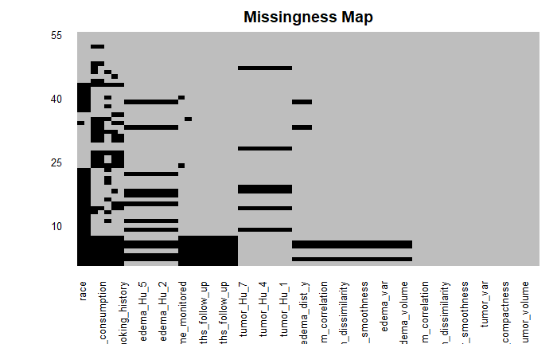

```r
dataset_images_merge_red <- dataset_images_merge

# Missing values
missmap(dataset_images_merge_red, col=c("black", "grey"), legend=FALSE)
```

```r
cause_of_death_index <- which(names(dataset_images_merge_red) == 'cause_of_death_at_12months_follow_up', arr.ind = TRUE)
vital_status_index <- which(names(dataset_images_merge_red) == 'vital_status_at_12months_follow_up', arr.ind = TRUE)
life_expectancy_index <- which(names(dataset_images_merge_red) == 'life_expectancy', arr.ind = TRUE)

dataset_images_merge_red[c(cause_of_death_index, vital_status_index, life_expectancy_index)] <- NULL

# Elminar las entradas con más del 30% de las variables con NA
# Tamaño del dataset antes de eliminar entradas
dim(dataset_images_merge_red)
```

```
[1] 55 66
```

```r
dataset_images_merge_red <- dataset_images_merge_red[which(rowMeans(!is.na(dataset_images_merge_red)) > 0.7), ]
dataset_images_merge <- dataset_images_merge[which(rowMeans(!is.na(dataset_images_merge[, -c(cause_of_death_index, vital_status_index, life_expectancy_index)])) > 0.7), ]

# Eliminar variables con más del 40% de los valores con NA
dataset_images_merge_red <- cbind(dataset_images_merge_red[, which(colMeans(!is.na(dataset_images_merge_red[,])) > 0.6)], dataset_images_merge[,c(cause_of_death_index, vital_status_index, life_expectancy_index)])

cause_of_death_index <- which(names(dataset_images_merge_red) == 'cause_of_death_at_12months_follow_up', arr.ind = TRUE)
vital_status_index <- which(names(dataset_images_merge_red) == 'vital_status_at_12months_follow_up', arr.ind = TRUE)
life_expectancy_index <- which(names(dataset_images_merge_red) == 'life_expectancy', arr.ind = TRUE)

numeric_var_indexes_all <- c(which(sapply(dataset_images_merge_red, class) == 'numeric', arr.ind = TRUE), which(sapply(dataset_images_merge_red, class) == 'integer', arr.ind = TRUE))
numeric_var_indexes <- numeric_var_indexes_all[-which(numeric_var_indexes_all ==  life_expectancy_index, arr.ind = TRUE)]

non_numeric_var_indexes_all <- which(sapply(dataset_images_merge_red, class) == 'factor', arr.ind = TRUE)
non_numeric_var_indexes <- non_numeric_var_indexes_all[-which(non_numeric_var_indexes_all ==  cause_of_death_index, arr.ind = TRUE)]
non_numeric_var_indexes <- non_numeric_var_indexes[-which(non_numeric_var_indexes ==  vital_status_index, arr.ind = TRUE)]

# Tamaño del dataset tras eliminar entradas
dim(dataset_images_merge_red)
```

```
[1] 51 66
```

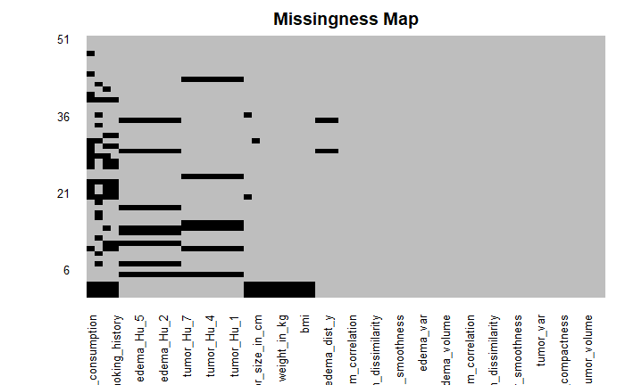

```r
missmap(dataset_images_merge_red, col=c("black", "grey"), legend=FALSE)

# Histogramas de las variables numéricas
par(mfrow=c(1, 4))
```

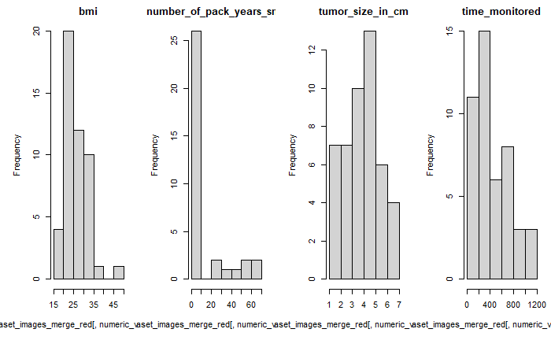

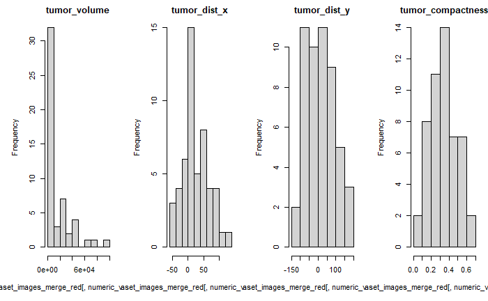

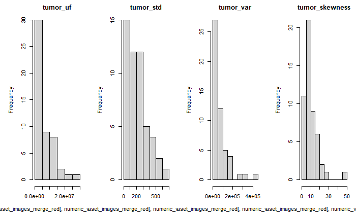

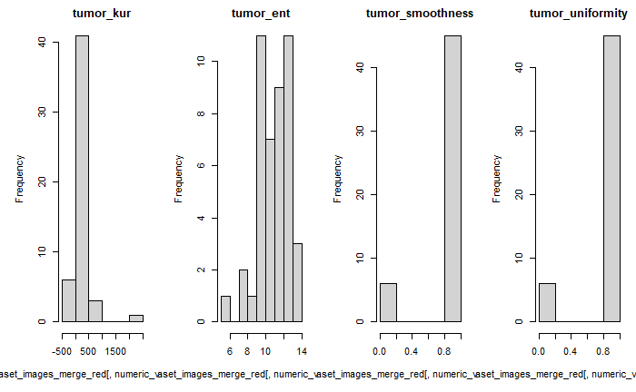

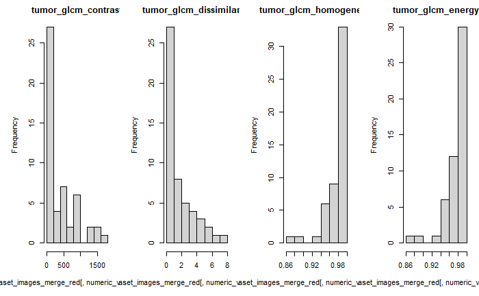

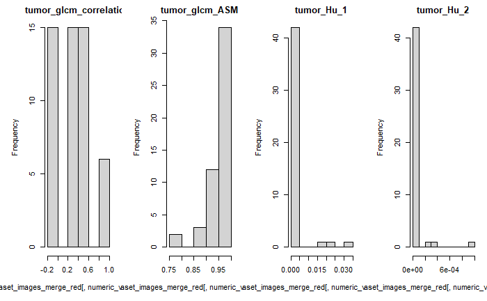

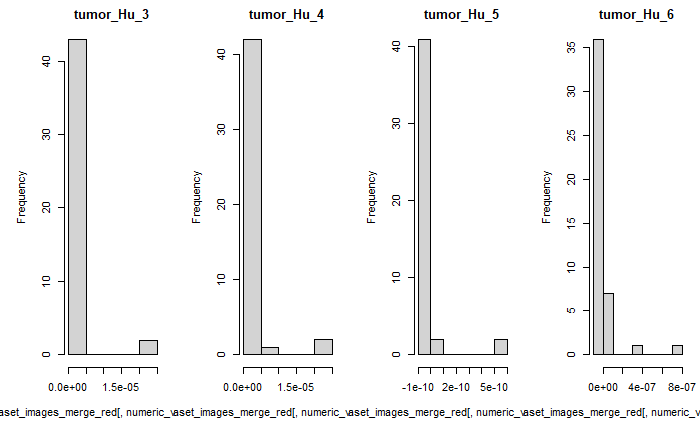

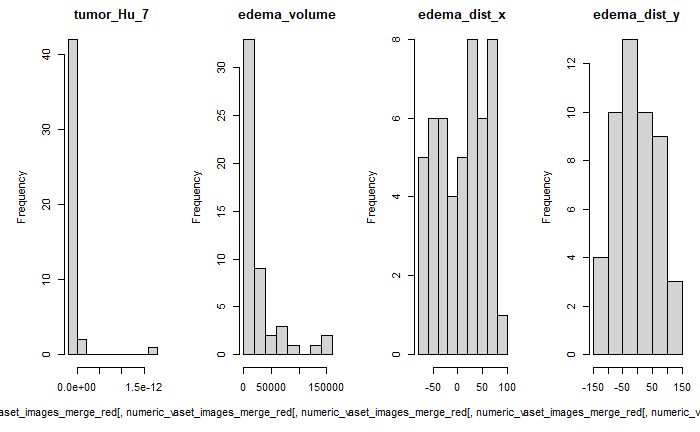

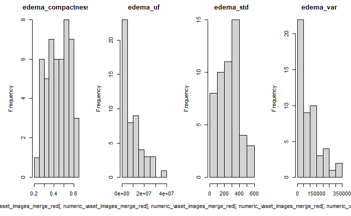

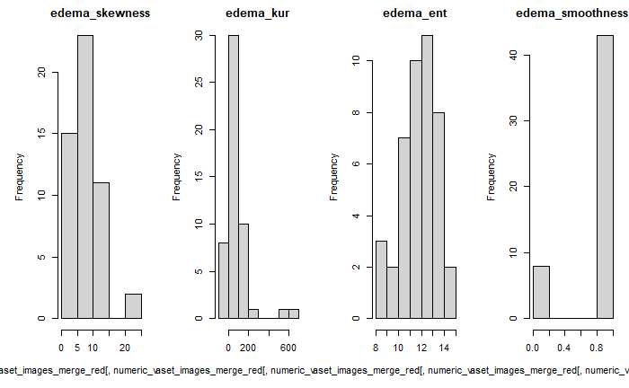

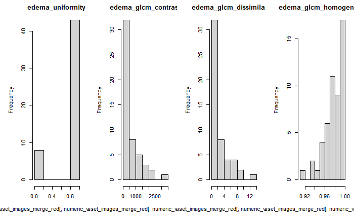

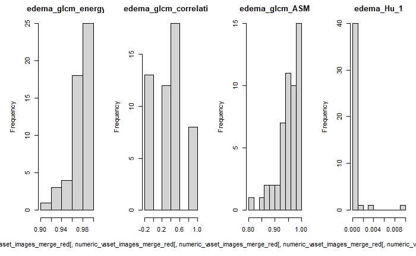

[2 more figures not shown]

```r
for(i in 1:length(numeric_var_indexes)) {
    hist(dataset_images_merge_red[,numeric_var_indexes[i]], main=names(dataset_images_merge_red)[numeric_var_indexes[i]])
}
```